# Using Computer Vision Algorithms for Plant Detection and Counting

## Using Computer Vision Algorithms for Plant Detection and Counting

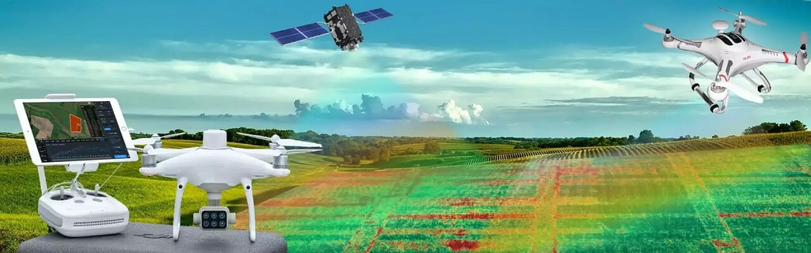

Morphological operations are widely used techniques in image processing to detect and count objects, including plants in drone images. A general approach on how morphological operations can be used for this purpose is presented below:

- Image preprocessing: Before applying morphological operations, it is recommended to perform preprocessing steps on the image to improve the quality of the results. This may include reducing noise with a smoothing filter, such as the Gaussian filter, and segmenting the image to highlight regions of interest, such as plants.
- Image binarization: Binarization is the process of converting the image into a black and white image, where objects of interest are represented as white pixels and the background as black pixels. There are different binarization methods available, such as the Otsu method or applying a fixed threshold. The method chosen will depend on the characteristics of the image.
- Morphological operations: The two most commonly used morphological operations for plant detection and counting are erosion and dilation.
- Erosion: Erosion is used to remove small details and noise from the binary image. It wears away the edges of objects, reducing their size. By applying erosion, small objects such as small blobs or noises disappear, while larger objects such as plants are preserved.
- Dilation: Dilation is used to fill holes and increase the size of objects in the binary image. It expands the edges of objects, making them larger. By applying dilation, objects become more cohesive and connected.
- These operations can be applied in sequence to improve plant segmentation. The order of application can vary depending on the image and the desired result. Multiple iterations of erosion and dilation can be performed to achieve the desired result.
- Plant detection and counting: After applying morphological operations, regions of interest that correspond to plants can be identified in the resulting binary image. There are several methods you can adopt to detect and count plants:
- Connected components: Using connected component labeling algorithms, it is possible to identify connected regions of white pixels in the binary image. Each identified region represents a plant.
- Object counting: You can use object counting algorithms to identify and count the objects detected in the binary image. These algorithms can count the number of regions or segments in the image, each of which represents a plant.

Remember to adjust the parameters of the morphological operations, such as the size of the structuring element used in erosion and dilation, to suit the size and shape of the plants you are trying to detect.

# Plant detection

Let's start by installing rasterio.

```python
!pip install rasterio
```

```
Downloading rasterio-1.3.10-cp310-cp310-manylinux2014_x86_64.whl (21.5 MB)
   ━━━━━━━━━━━━━━━━━━━━━━━━━━━━━━━━━━━━━━━━ 21.5/21.5 MB 45.8 MB/s eta 0:00:00
Downloading snuggs-1.4.7-py3-none-any.whl (5.4 kB)
Downloading affine-2.4.0-py3-none-any.whl (15 kB)
```

Now, let's connect Drive to access the files that will be used:

```python
from google.colab import drive
drive.mount('/content/drive')
```

We install the libraries that we are going to use

```python
from skimage.filters import threshold_multiotsu
from skimage.measure import label, regionprops
from skimage.morphology import closing, square
from skimage.color import label2rgb
import matplotlib.pyplot as plt
import rasterio
import geopandas as gpd
import pandas as pd
import numpy as np
import os
from rasterio.plot import show
from rasterio.mask import mask
import json
import cv2
```

Then we set the path of the image we are going to use:

```python
path_img = '/content/drive/MyDrive/Datasets/Rice Detection/2018-08-14_ARI80_20m_Orthomosaic.tif'
```

With rasterio we open the image and draw it with matplotlib:

```python
src_img = rasterio.open(path_img)
```

```python
img = src_img.read()
```

```python
img.shape
```

```
(4, 10687, 19876)
```

```python
img = img.transpose([1,2,0])
```

After opening the image, we present:

```
(-0.5, 19875.5, 10686.5, -0.5)
```

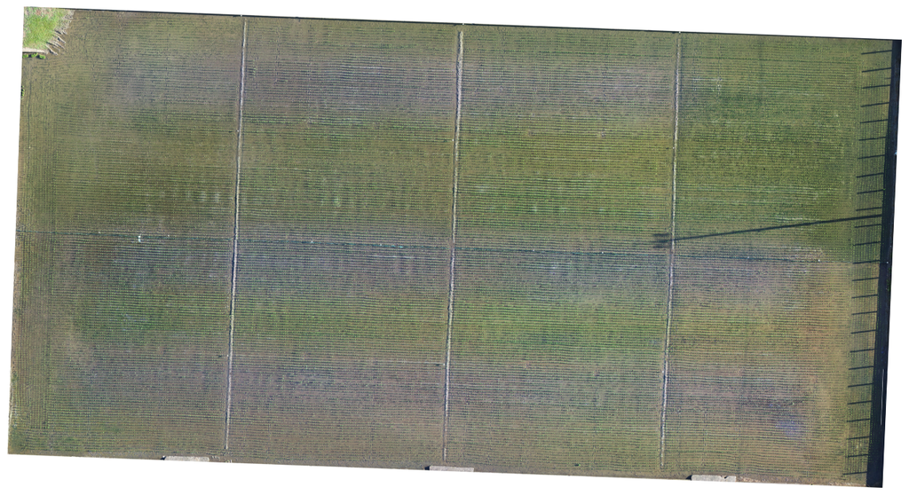

```python
plt.figure(figsize=[16,16])
plt.imshow(img)
plt.axis('off')
```

Let's now import the vector containing the fields that will divide the image:

```python
path_lotes = '/content/drive/MyDrive/Datasets/Rice Detection/Lotes.shp'
```

```python
gdf = gpd.read_file(path_lotes)
```

Presentamos la delimitación de estos lotes:

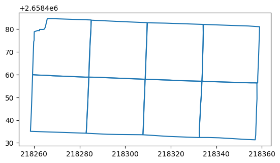

```python
gdf.boundary.plot()
```

We will now use the polygon of each field to crop the image, generating an image for each field. We will create a folder to store these new images:

```python
if not os.path.isdir('/content/Lotes_imgs'):
    os.mkdir('/content/Lotes_imgs')
```

With Geopandas and Raster we will cut out the images with each polygon and save them as a new image:

```python
for feat in json.loads(gdf.to_json())['features']:

  name_poly = 'Lote_' + str(feat['properties']['Lote'])
  coords = [feat['geometry']]

  with rasterio.open(path_img) as src:
    out_img, out_transform = mask(dataset=src, shapes=coords, crop=True)
    out_meta = src.meta.copy()

  out_meta.update({"driver": "GTiff",
                      "height": out_img.shape[1],
                      "width": out_img.shape[2],
                      "compress":'lzw',
                      "transform": out_transform})
  path_to_save_clip = os.path.join('/content/Lotes_imgs',name_poly + '.tif')
  print(path_to_save_clip)

  with rasterio.open(path_to_save_clip, "w", **out_meta) as dest:
      dest.write(out_img)
  del out_img, out_meta,src
```

```
/content/Lotes_imgs/Lote_A.tif
/content/Lotes_imgs/Lote_B.tif
/content/Lotes_imgs/Lote_C.tif
/content/Lotes_imgs/Lote_D.tif
/content/Lotes_imgs/Lote_E.tif
/content/Lotes_imgs/Lote_F.tif
/content/Lotes_imgs/Lote_G.tif
/content/Lotes_imgs/Lote_H.tif
```

We will now process and identify plants for each of the images. The resulting Points for each plant will be saved in a single dataframe with the Lot information for each point. Let's review the steps that will be performed in a for loop for each image:

- Open the image with the raster and obtain the green band (G)
- Apply the Otsu boundary algorithm.
- Binarize the image according to the found boundary.
- Apply the morphological operations of erosion and dilation.
- Separate the unique regions that remain in the image.
- For each region we obtain the central point
- We convert the value of the central point of rows and columns to latitude and longitude.
- We store this information together with the name of the field to which that point belongs in a geodataframe.

```python
ls_x = []
ls_y = []
ls_lote = []
imgs_to_pred = os.listdir('/content/Lotes_imgs')
for images in imgs_to_pred:
  src = rasterio.open(os.path.join('/content/Lotes_imgs',images))
  print(images.split('.')[0])
  raster = src.read()
  raster = raster.transpose([1,2,0])
  R = raster[:,:,0]
  G = raster[:,:,1]
  B = raster[:,:,2]
  G = np.where(G == 255,0,G)
  thresh = threshold_multiotsu(G)
  binary = G > thresh[1]
  binary = binary.astype('uint8')
  kernel = cv2.getStructuringElement(cv2.MORPH_ELLIPSE, (3,3))
  horizontal = cv2.dilate(binary, kernel, iterations = 3)
  horizontal = cv2.erode(horizontal, kernel,  iterations = 6)
  horizontal = cv2.dilate(horizontal, kernel, iterations = 4)
  horizontal = cv2.erode(horizontal, kernel,  iterations = 6)
  label_image = label(horizontal)
  for region in regionprops(label_image):
      if region.area >= 1:
        y0, x0 = region.centroid
        xs, ys = rasterio.transform.xy(src.transform, y0, x0)
        ls_x.append(xs)
        ls_y.append(ys)
        ls_lote.append(images.split('.')[0])
```

```
Lote_G
Lote_D
Lote_C
Lote_E
Lote_B
Lote_A
Lote_H
Lote_F
```

```python
df_xy = pd.DataFrame([])
df_xy['x'] = ls_x
df_xy['y'] = ls_y
df_xy['Lote'] = ls_lote
gdf_points = gpd.GeoDataFrame(df_xy, geometry=gpd.points_from_xy(df_xy['x'], df_xy['y']))
gdf_points = gdf_points.set_crs(src.crs.to_dict()['init'])
```

```python
gdf_points
```

|  | x | y | Lote | geometry |
| --- | --- | --- | --- | --- |
| 0 | 218334.615946 | 2.658457e+06 | Lote_G | POINT (218334.616 2658456.883) |
| 1 | 218334.804559 | 2.658457e+06 | Lote_G | POINT (218334.805 2658456.881) |
| 2 | 218335.021719 | 2.658457e+06 | Lote_G | POINT (218335.022 2658456.859) |
| 3 | 218334.396841 | 2.658457e+06 | Lote_G | POINT (218334.397 2658456.865) |
| 4 | 218335.221933 | 2.658457e+06 | Lote_G | POINT (218335.222 2658456.846) |
| ... | ... | ... | ... | ... |
| 61626 | 218331.132522 | 2.658433e+06 | Lote_F | POINT (218331.133 2658432.674) |
| 61627 | 218330.313555 | 2.658433e+06 | Lote_F | POINT (218330.314 2658432.676) |
| 61628 | 218330.942742 | 2.658433e+06 | Lote_F | POINT (218330.943 2658432.676) |
| 61629 | 218331.574971 | 2.658433e+06 | Lote_F | POINT (218331.575 2658432.641) |
| 61630 | 218332.252271 | 2.658433e+06 | Lote_F | POINT (218332.252 2658432.668) |

61631 rows × 4 columns

# Plant size analysis

After identifying the locations of each plant in the image, we will analyze the size of the leaf area per plant. From the green band we apply otsu to find the separation threshold and generate the binarized image. We save it in a .tif file.

```python
G = img[:,:,1]
G = np.where(G == 255,0,G)
thresh = threshold_multiotsu(G)
binary_img = G > thresh[1]
binary_img = binary_img.astype('uint8')
```

```python
binary_img = binary_img[np.newaxis,:,:]
```

```python
out_meta_img = src_img.meta.copy()
out_meta_img.update({"driver": "GTiff",
                      "height": binary_img.shape[1],
                      "width": binary_img.shape[2],
                      "count": 1,
                      "compress":'lzw'})
path_to_save = os.path.join('/content/Mask_veg.tif')

with rasterio.open(path_to_save, "w", **out_meta_img) as dest:
    dest.write(binary_img)
```

Now we create a 10cm zone of influence around the point.

```python
gdf_points.geometry = gdf_points['geometry'].buffer(0.10)
```

```python
gdf_points
```

|  | x | y | Lote | geometry |
| --- | --- | --- | --- | --- |
| 0 | 218334.615946 | 2.658457e+06 | Lote_G | POLYGON ((218334.716 2658456.883, 218334.715 2... |
| 1 | 218334.804559 | 2.658457e+06 | Lote_G | POLYGON ((218334.905 2658456.881, 218334.904 2... |
| 2 | 218335.021719 | 2.658457e+06 | Lote_G | POLYGON ((218335.122 2658456.859, 218335.121 2... |
| 3 | 218334.396841 | 2.658457e+06 | Lote_G | POLYGON ((218334.497 2658456.865, 218334.496 2... |
| 4 | 218335.221933 | 2.658457e+06 | Lote_G | POLYGON ((218335.322 2658456.846, 218335.321 2... |
| ... | ... | ... | ... | ... |
| 61626 | 218331.132522 | 2.658433e+06 | Lote_F | POLYGON ((218331.233 2658432.674, 218331.232 2... |
| 61627 | 218330.313555 | 2.658433e+06 | Lote_F | POLYGON ((218330.414 2658432.676, 218330.413 2... |
| 61628 | 218330.942742 | 2.658433e+06 | Lote_F | POLYGON ((218331.043 2658432.676, 218331.042 2... |
| 61629 | 218331.574971 | 2.658433e+06 | Lote_F | POLYGON ((218331.675 2658432.641, 218331.674 2... |
| 61630 | 218332.252271 | 2.658433e+06 | Lote_F | POLYGON ((218332.352 2658432.668, 218332.352 2... |

61631 rows × 4 columns

For each plant, let's find the leaf area and percentage of leaf area:

```python
src.res
```

```
(0.00511534532489187, 0.005105304523082099)
```

```python
area_foliar_list = []
percentual_list = []
src = rasterio.open('/content/Mask_veg.tif')
for feat in json.loads(gdf_points.to_json())['features']:
  out_img, out_transform = mask(dataset=src, shapes=[feat['geometry']], crop=True)
  valid_values = out_img[out_img != 255]
  area_foliar = valid_values.sum() * src.res[0] * src.res[1]
  area_foliar_list.append(area_foliar)
  area_total = len(valid_values) * src.res[0] * src.res[1]
  percent = (area_foliar*100) / area_total
  percentual_list.append(percent)
  print(percent)
```

[output not shown]

[output cut: 4946 more lines]

```
33.72093023255813
20.784641068447414
13.549459684123024
13.333333333333336
15.083333333333334
18.80199667221298
13.963210702341135
18.37073981712386
11.823480432972522
12.239800166527893
12.624584717607972
11.175496688741722
16.63907284768212
21.017514595496248
17.901748542880934
```

We add these values to the geodataframe:

```python
gdf_points['LAI'] = area_foliar_list
gdf_points['LAI_percent'] = percentual_list
```

We will use the mean and standard deviation to define the leaf area size classes:

```python
mean_value = gdf_points['LAI'].mean()
std_value = gdf_points['LAI'].std()
```

```python
mean_list = []
for i,row in gdf_points.iterrows():
  value = row['LAI']
  if value < (mean_value-std_value) :
    mean_list.append(0)
  elif (value >= (mean_value-std_value)) and (value < mean_value):
    mean_list.append(1)
  elif (value >= mean_value) and (value < (mean_value+std_value)):
    mean_list.append(2)
  elif value >= (mean_value+std_value):
    mean_list.append(3)
```

```python
gdf_points['Classified'] = mean_list
```

```python
gdf_points.geometry = gdf_points.geometry.centroid
```

We can now save the geographic data frame to a shapefile and download it.

```python
gdf_points
```

|  | x | y | Lote | geometry | LAI | LAI_percent | Classified |
| --- | --- | --- | --- | --- | --- | --- | --- |
| 0 | 218334.615946 | 2.658457e+06 | Lote_G | POINT (218334.616 2658456.883) | 0.006686 | 21.315570 | 2 |
| 1 | 218334.804559 | 2.658457e+06 | Lote_G | POINT (218334.805 2658456.881) | 0.006242 | 19.883527 | 2 |
| 2 | 218335.021719 | 2.658457e+06 | Lote_G | POINT (218335.022 2658456.859) | 0.007573 | 24.227235 | 2 |
| 3 | 218334.396841 | 2.658457e+06 | Lote_G | POINT (218334.397 2658456.865) | 0.006973 | 22.250000 | 2 |
| 4 | 218335.221933 | 2.658457e+06 | Lote_G | POINT (218335.222 2658456.846) | 0.006999 | 22.389307 | 2 |
| ... | ... | ... | ... | ... | ... | ... | ... |
| 61626 | 218331.132522 | 2.658433e+06 | Lote_F | POINT (218331.133 2658432.674) | 0.003970 | 12.624585 | 1 |
| 61627 | 218330.313555 | 2.658433e+06 | Lote_F | POINT (218330.314 2658432.676) | 0.003526 | 11.175497 | 1 |
| 61628 | 218330.942742 | 2.658433e+06 | Lote_F | POINT (218330.943 2658432.676) | 0.005249 | 16.639073 | 1 |
| 61629 | 218331.574971 | 2.658433e+06 | Lote_F | POINT (218331.575 2658432.641) | 0.006581 | 21.017515 | 2 |
| 61630 | 218332.252271 | 2.658433e+06 | Lote_F | POINT (218332.252 2658432.668) | 0.005615 | 17.901749 | 1 |

61631 rows × 7 columns

```python
path_shp = '/content/shapefile'
if not os.path.isdir(path_shp):
  os.mkdir(path_shp)
```

```python
gdf_points.to_file("/content/shapefile/Plants.shp")
```

```python
!zip -r /content/shapefile.zip /content/shapefile
from google.colab import files
files.download("/content/shapefile.zip")
```

```
  adding: content/shapefile/ (stored 0%)
  adding: content/shapefile/Plants.shx (deflated 71%)
  adding: content/shapefile/Plants.dbf (deflated 82%)
  adding: content/shapefile/Plants.cpg (stored 0%)
  adding: content/shapefile/Plants.prj (deflated 36%)
  adding: content/shapefile/Plants.shp (deflated 51%)
```

## Field Analysis

Now let's perform an analysis by field. Let's find the number of plants per field. To do this, we group the number of plants in each field.

```python
df_count = gdf_points.groupby('Lote').count()
```

```python
df_count
```

| Lote | x | y | geometry | LAI | LAI_percent | Classified |
| --- | --- | --- | --- | --- | --- | --- |
| Lote_A | 5305 | 5305 | 5305 | 5305 | 5305 | 5305 |
| Lote_B | 8516 | 8516 | 8516 | 8516 | 8516 | 8516 |
| Lote_C | 8410 | 8410 | 8410 | 8410 | 8410 | 8410 |
| Lote_D | 7232 | 7232 | 7232 | 7232 | 7232 | 7232 |
| Lote_E | 8332 | 8332 | 8332 | 8332 | 8332 | 8332 |
| Lote_F | 9221 | 9221 | 9221 | 9221 | 9221 | 9221 |
| Lote_G | 7698 | 7698 | 7698 | 7698 | 7698 | 7698 |
| Lote_H | 6917 | 6917 | 6917 | 6917 | 6917 | 6917 |

We will also get the leaf area per field:

```python
gdf_points_to_sum = gdf_points.drop(columns='geometry')
```

```python
df_sum = gdf_points_to_sum.groupby('Lote').sum()
```

```python
df_sum['LAI']
```

| Lote | LAI |
| --- | --- |
| Lote_A | 11.807998 |
| Lote_B | 48.828739 |
| Lote_C | 54.199579 |
| Lote_D | 42.880069 |
| Lote_E | 59.483193 |
| Lote_F | 72.384408 |
| Lote_G | 50.486857 |
| Lote_H | 33.403915 |

**dtype:** float64

```python
df_count.reset_index(inplace=True)
df_sum.reset_index(inplace=True)
```

```python
gdf['Lote'] = gdf['Lote'].apply(lambda x: f"Lote_{x}")
```

Let's remove the columns that won't be needed.

```python
df_count.drop(columns=['y','geometry','LAI','LAI_percent','Classified'], inplace=True)
```

```python
df_sum.drop(columns=['y','x','LAI_percent','Classified'], inplace=True)
```

```python
df_sum
```

|  | Lote | LAI |
| --- | --- | --- |
| 0 | Lote_A | 11.807998 |
| 1 | Lote_B | 48.828739 |
| 2 | Lote_C | 54.199579 |
| 3 | Lote_D | 42.880069 |
| 4 | Lote_E | 59.483193 |
| 5 | Lote_F | 72.384408 |
| 6 | Lote_G | 50.486857 |
| 7 | Lote_H | 33.403915 |

```python
df_count
```

|  | Lote | x |
| --- | --- | --- |
| 0 | Lote_A | 5305 |
| 1 | Lote_B | 8516 |
| 2 | Lote_C | 8410 |
| 3 | Lote_D | 7232 |
| 4 | Lote_E | 8332 |
| 5 | Lote_F | 9221 |
| 6 | Lote_G | 7698 |
| 7 | Lote_H | 6917 |

And let's apply a join to the count data frame and the sum of sheet area data frame:

```python
gdf = gdf.merge(df_count, how='inner', on='Lote' )
gdf = gdf.merge(df_sum, how='inner', on='Lote' )
```

```python
gdf
```

|  | id | Lote | geometry | x | LAI |
| --- | --- | --- | --- | --- | --- |
| 0 | 1 | Lote_A | POLYGON ((218259.378 2658459.971, 218259.885 2... | 5305 | 11.807998 |
| 1 | 2 | Lote_B | POLYGON ((218282.899 2658434.262, 218258.453 2... | 8516 | 48.828739 |
| 2 | 3 | Lote_C | POLYGON ((218284.095 2658458.842, 218285.952 2... | 8410 | 54.199579 |
| 3 | 4 | Lote_D | POLYGON ((218284.113 2658458.901, 218284.165 2... | 7232 | 42.880069 |
| 4 | 5 | Lote_E | POLYGON ((218309.773 2658482.730, 218317.645 2... | 8332 | 59.483193 |
| 5 | 6 | Lote_F | POLYGON ((218308.771 2658457.897, 218310.687 2... | 9221 | 72.384408 |
| 6 | 7 | Lote_G | POLYGON ((218333.718 2658457.091, 218335.593 2... | 7698 | 50.486857 |
| 7 | 8 | Lote_H | POLYGON ((218333.695 2658457.146, 218333.809 2... | 6917 | 33.403915 |

```python
gdf.rename(columns={'x': 'Qtd_plantas'}, inplace=True)
```

This way we have the DataFrame ready:

```python
gdf
```

|  | id | Lote | geometry | Qtd_plantas | LAI |
| --- | --- | --- | --- | --- | --- |
| 0 | 1 | Lote_A | POLYGON ((218259.378 2658459.971, 218259.885 2... | 5305 | 11.807998 |
| 1 | 2 | Lote_B | POLYGON ((218282.899 2658434.262, 218258.453 2... | 8516 | 48.828739 |
| 2 | 3 | Lote_C | POLYGON ((218284.095 2658458.842, 218285.952 2... | 8410 | 54.199579 |
| 3 | 4 | Lote_D | POLYGON ((218284.113 2658458.901, 218284.165 2... | 7232 | 42.880069 |
| 4 | 5 | Lote_E | POLYGON ((218309.773 2658482.730, 218317.645 2... | 8332 | 59.483193 |
| 5 | 6 | Lote_F | POLYGON ((218308.771 2658457.897, 218310.687 2... | 9221 | 72.384408 |
| 6 | 7 | Lote_G | POLYGON ((218333.718 2658457.091, 218335.593 2... | 7698 | 50.486857 |
| 7 | 8 | Lote_H | POLYGON ((218333.695 2658457.146, 218333.809 2... | 6917 | 33.403915 |

We can save it in a json file:

```python
gdf.to_file("/content/Lotes_infos.json",driver="GeoJSON")
```

And draw the polygons using the number of plants as a property:

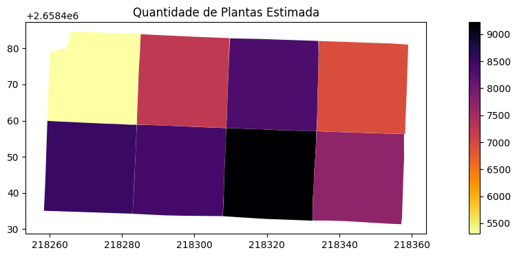

```python
fig, ax = plt.subplots(figsize=(16,4))
gdf.plot("Qtd_plantas",legend=True, cmap='inferno_r',ax = ax)
ax.title.set_text('Quantidade de Plantas Estimada')
```

Let's also plot the estimated total leaf area:

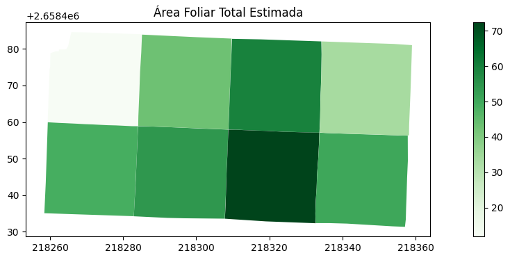

```python
fig, ax = plt.subplots(figsize=(16,4))
gdf.plot("LAI",legend=True, cmap='Greens',ax = ax)
ax.title.set_text('Área Foliar Total Estimada')
```